# Intro to CDA in R: Multinomial and Ordinal Models

16/12/2019

- I received a few of the Rmarkdown files
- Hopefully I will receive other files…
- Feedback will come then on the 6th of January

## Previously on CDA

### Binary model diagnostics: Confusion table

- False positives and False negatives
- Goal: get at a model with good accuracy

### Multinomial logit model

- Multinomial data (mutually exclusive and exhaustive non-ordered categories \(J\))
- Set a restriction on one of those categories (for identification; the *reference*)
- As in binary models, interpret the marginal probability effects
- Always interpret in relation to *reference* category

## More on multinomial Models

## Independence of Irrelevant Alternatives (IIA)

- There is an implicit restrictive assumption (resulting from the specific structure of outcome probabilites)
- Comparing alternatives \(j\) and \(m\) only depend on the attributes ot these two alternatives, not on other alternatives
- Example of car v. red or blue bus?
- Model predicts too high a joint probability for similar alternatives
- Model is misspecified (which means we lose the nice properties of MLE)

## Hausman Specification Test

- Inconsistency is the problem
- If an alternative is irrelevant, exclusion of it should not change parameter estimates systematically
- \(\hat{\gamma}_r\) and \(\hat{Var}(\hat{\gamma}_r)\) for the reduced model and \(\hat{\gamma}_f\) and \(\hat{Var}(\hat{\gamma}_f)\)
- Compute \(H=(\hat{\gamma}_f - \hat{\gamma}_r)'[\hat{Var}(\hat{\gamma}_r) - \hat{Var}(\hat{\gamma}_f)]^{-1}(\hat{\gamma}_f - \hat{\gamma}_r)\)
- \(H\) is distributed as \(\chi^2\) with degrees of freedom equal to the total number of alternatives in \(\hat{\gamma}_f%\)
- a model estimated with all the alternatives
- plus a model estimated on a subset of alternatives

## Alternatives to address this

1. Multinomial probit (assumption of independent errors in latent variable model is relaxed)
2. Mixed logit models (includes other “random” terms in the model which are function of the choice variables)
3. Nested logit models (consider a tree-like data structure for sequential decisions)

## Ordered response models

## Ordinal Variables

- Here we deal with dependent variables with a *finite number of categories* \(J+1\) with a *natural ordering*
- For example, from low to high (or vice versa)
- \(y_i\) is an ordinal variable when:
1. Outcome is ordered
2. Assigned numbers have no particular meaning (arbitrary)
3. Transformations must only preserve the *order*

## Ordinal Variables

- \(J+1\) categories \["0"<"1"<"2"<...<"J"\]
- If we analyzed this through multinomial models, we would ignore information on the order
- Linear models are inappropriate because the difference between \(0\) and \(1\) is not the same as from \(1\) to \(2\)

## Probit Models

## Latent (unobserved) model

- Important model in microeconometrics
- Let’s assume we have a latent (continuous) but unobserved variable \(y_i^*\)
- We can call it, for example, “utility” (i.e. some kind of measure of how satisfied we are with a given choice; or how much do we “benefit” from such a choice)
- We can say this is related to a linear index function \[y_i^*=x_i'\beta + u_i\]

## Remember: Binary Probit model

- So we define a probit model saying that \[y_i=I(y_i^* \ge 0)\]
- we say that \(y_i=1\) if \(y_i^* \ge 0\)
- and that \(y_i=0\) if \(y_i^* \lt 0\)

## Binary Probit model

- Therefore \(\pi_i=P(y_i^* \ge 0 | x_i) = P(x_i'\beta + u_i \ge 0 |x_i) = P(u_i \ge -x_i\beta | x_i)\)
- Assume that \(u_i\) are independently and normally distributed with variance \(\sigma^2\) then:
- and we have that \(P(\frac{u_i}{\sigma} \ge \frac{-x_i\beta}{\sigma} | x_i)=\Phi(\frac{x_i'\beta}{\sigma})\)
- when we further fix \(\sigma=1\), we get the probit model!
- just a tool to derive the conditional probability model

## Multinomial Probit Models I

- Relax assumption of independence of error terms \(u_{ij}\)
- Probit specification of choice probabilities
- Choice does make a difference here because we can specify a flexible correlation structure
- Assume utility function \(U_{ij}=\mu_{ij}+u_{ij}=z_{ij}'\gamma + x_i'\beta_j + u_{ij}\)
- Under random utility maximization, alternative \(j\) is chosen with probability \[\pi_{ij}=P(y_i=j|x_i+z_{i1},...,z_{iJ})\] \[=P(U_{ij} \gt U_{im}, \forall m \ne j | x_i+z_{i1},...,z_{iJ})\]

## Multinomial Probit Models II

- Assume: \(u_{ij}\) are jointly normally distributed with mean 0 and flexible covariance matrix \(\Sigma\)
- Not all elements of the \(\Sigma\) can be identified, so we make some restrictions (base category)
- We can include choice-specific and individual-specific variables into the analysis
- More easily said than done
- No ready made package that does this in R, as in Stata

## Ordered Probit Models I

- We do not observe \(y_i^*\), but we observed the discrete values \(y_i \in \{0,1,2,...,J\}\)
- Threshold Mechanism relating \(y_i^*\) and \(y_i\)
- We say: \(y_i=j\) if and only if \(\kappa_{j-1} < y_i^* < \kappa_j\) for \(j=1,2,...,J\)

## Ordered Probit Models II

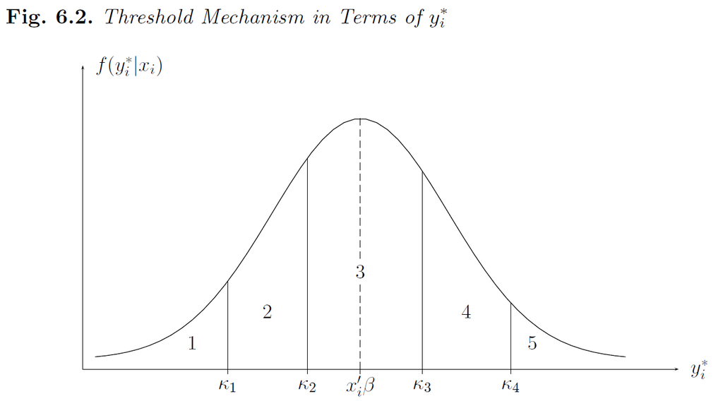

- Taken from Winkelmann and Boes’ p. 175

## Ordered Probit Models III

- Conditional probability function for latent variable \(f(y_i^* | x_i)\)
- Example with \(J=5\) intervals
- We specify a distribution function for the error term \(F(u)\)
- The probability of some outcome is the area under the density function between two relevant thresholds
- \(\pi_{ij} = P(y_i=j|x_i)=F(\kappa_j-x_i'\beta) - F(\kappa_{j-1}-x_i'\beta)\) for \(j=1,...,J\)
- Ordered probit and ordered logit are simply different specifications for \(F(u)\)

## Ordered Probit Models III

\[\pi_{ij}=\Phi(\frac{\kappa_j-x_i'\beta}{\sigma})-\Phi(\frac{\kappa{j-1}-x_i'\beta}{\sigma})\] for \(j=1,...,J\)

- As in the binary case we set \(\sigma=1\) and we have the standard normal distribution
- No intercept term is included to achieve identification of the threshold parameters

## Another alternative

## Ordered Logit Model

- Similar to probit
- \(\varepsilon_i\) follows logistic distribution
- Therefore \(\pi_{ij} = \Lambda(\mu_{j+1}-x_{(i)}'\beta) - \Lambda(\mu_{j}-x_{(i)}'\beta)\) for \(j=1,...,J\)

## Proportional odds model

- Think of two events: \(\{y_i \le j \}\) and \(\{y_i \gt j\}\) for \(j \in \{0,1,2,...,J\}\)
- We can compute then the ratio of probabilities associated to those events: odds!
- As always, assuming log-odds are linear function of our covariates or predictors \[ln[\frac{P(y_i \le j)}{P(y_i \gt j)}]=\mu_{j+1}-x_{(i)}'\beta\]
- This implies (or is the same as) \[exp(\mu_{j+1}-x_{(i)}'\beta$)=exp(\mu_{j+1})exp(-x_{(i)}'\beta)\]

## Proportional odds model

- We have specific intercepts for each possible odds \(\mu_1<\mu_2<...<\mu_J\) (the information vector \(x_{(i)}\) does not have an intercept)
- Relative odds then \[\frac{P(y_i \le j)/P(y_i \gt j)}{P(y_i \le h)/P(y_i \gt h)}=\frac{exp(\mu_{j+1})}{exp(\mu_{h+1})}\]
- The term doesn’t depend on explanatory variables

## Estimation

- Again we make use of ML principle
- We obtain consistent, asymptotically efficient and asymptotically normally distributed estimators

## Interpretation I

- Interpretation in terms of latent model might seem appropriate, but the \(\beta\)s are only identified up to scale
- Compensating variation: variation in two regressors such that the latent variable does not change
- \(0=\beta_l \Delta x_{il} + \beta_m \Delta x_{im}\) or \(\frac{\Delta x_{il}}{\Delta x_{im}}=-\frac{\beta_m}{\beta_l}\)
- How much should an explanatory variable change to reach the next higher response category \((\kappa_j-\kappa_{j-1})/\beta_l\)
- Smaller this ratio, smaller maximum change in covariate \(x_{il}\) to move from category \(y_i=j\) to \(y_i=j+1\)

## Interpretation II

- Better yet: discrete or marginal probability effects \(\Delta_{ij}=P(y_i=j|x_i+\Delta x_{il})-P(y_i=j|x_i)\)
- Marginal probability effect: \[MPE_{ijl} = \frac{\partial \pi_{ij}}{\partial x_{il}}=[f(\kappa_{j-1}-x_i'\beta)-f(\kappa_j-x_i'\beta)]\beta_j\] where \(f(z)=\frac{dF(z)}{\partial dz}\) is the density function

## Interpretation III

- MPEs are function of covariates (i.e. they vary across individuals)
- We want average marginal probability effects (AMPE’s)
- Discrete change in probability can be approximated: \[\Delta \pi_{ij} = MPE_{ijl} \Delta x_{il}\]

## Let’s go to R

## Single index assumption

- Also called parallel regression assumption
- Same slope for all “levels” of \(j\)
- Constant relative magnitude of the MPE’s and equal for all levels \(j\) \[MPE_{ijk}/MPE_{ijh}=\beta_k/\beta_h\]
- We are assuming that some variable has the same effect at all levels of the distribution of \(y_i\) (e.g. income brings the same happiness across all levels of our happiness construct)
- Unrealistic!

## Overview of Flexi-Calender

```
      Date    Introduction                        Methods     Projects
1   14-Oct dies academicus                              -            -
2   21-Oct    Intro to CDA                              -            -
3   28-Oct               -  Tidyverse and some statistics            -
4   04-Nov               - More Tidyverse and binary data            -
5   11-Nov               -         Models for binary data            -
6  18-Nov*               -                                           -
7  25-Nov*               -                                           -
8   02-Dec               -                  Binary Models            -
9   09-Dec               -             Multinomial Models            -
10  16-Dec               -                 Ordinal Models            -
11  06-Jan               -  IRT and Latent Class Analysis            -
12  13-Jan               -      Count Models and Boosting            -
13  20-Jan               -                        ggplot2 Send exposés
14  27-Jan               -                    Survey Data            -
15  03-Feb               -                   Missing Data            -
16  10-Feb               -           Hands-on and Wrap-up            -
```

## Next on CDA

- Generalized threshold models
- Next class is on January 6th!
- Latent Class Analysis

### To Do:

- Send some advances on the projects before 24th December
- Read “Latent Class Analysis The Empirical Study of Latent Types, Latent Variables, and Latent Structures” by Leo Goodman
- Read “poLCA: An R Package for Polytomous Variable Latent Class Analysis” by Drew A. Linzer and Jeffrey B. Lewis